# CMPINF 2120 Final Project

## Ryan Negron

### Modeling Notebook

```python
import numpy as np
import pandas as pd
import matplotlib.pyplot as plt
import seaborn as sns
import statsmodels.formula.api as smf
from sklearn.preprocessing import StandardScaler
from sklearn.pipeline import Pipeline
from sklearn.preprocessing import PolynomialFeatures
from patsy import dmatrices
from sklearn.model_selection import StratifiedKFold
from sklearn.model_selection import cross_val_score
from sklearn.model_selection import GridSearchCV
from sklearn.preprocessing import OneHotEncoder
from sklearn.compose import ColumnTransformer
from sklearn.feature_selection import VarianceThreshold
from sklearn.linear_model import LogisticRegression
```

```python
team_stats = pd.read_csv('nfl-team-statistics.csv')
```

```python
team_stats_copy = team_stats.copy()
team_stats_copy['home_team']= team_stats['team']
team_stats_copy['away_team']= team_stats['team']
```

```python
stats_list = ['home_team', 'season', 'offense_completion_percentage', 'offense_ave_yards_gained_pass', 'offense_ave_yards_gained_run', 'defense_ave_yards_gained_pass', 'defense_ave_yards_gained_run', 'points_allowed']
```

```python
trim_stats = team_stats_copy[stats_list]
```

```python
nfl_raw ='https://raw.githubusercontent.com/nflverse/nfldata/master/data/games.csv'
nfl_game_data = pd.read_csv(nfl_raw)
```

```python
nfl_copy = nfl_game_data.copy()
```

```python
columns_list = ['game_id', 'season', 'total', 'overtime', 'away_team', 'home_team', 'total_line', 'roof', 'surface', 'temp', 'wind']
trim_nfl = nfl_copy[columns_list]
```

```python
nfl_df = trim_nfl.copy()
nfl_df['point_total_reached'] = np.where(trim_nfl.total - trim_nfl.total_line >= 0, 1,0)
```

```python
nfl_df_copy = nfl_df.copy()
nfl_df_copy.surface.fillna(value = 'UNKNOWN', inplace = True)
```

```python
nfl_df_copy['opponent'] = nfl_df_copy.loc[:, 'away_team']
```

```python
ready_nfl_df = nfl_df_copy.drop(columns = 'away_team')
```

```python
ready_nfl_df.loc[ ready_nfl_df['opponent'] == 'OAK', 'opponent'] = 'LV'
ready_nfl_df.loc[ ready_nfl_df['home_team'] == 'OAK', 'home_team'] = 'LV'
ready_nfl_df.loc[ ready_nfl_df['home_team'] == 'SD', 'home_team'] = 'LAC'
ready_nfl_df.loc[ ready_nfl_df['opponent'] == 'SD', 'opponent'] = 'LAC'
ready_nfl_df.loc[ ready_nfl_df['home_team'] == 'STL', 'home_team'] = 'LA'
ready_nfl_df.loc[ ready_nfl_df['opponent'] == 'STL', 'opponent'] = 'LA'
ready_nfl_df['overtime'] = np.where(ready_nfl_df.overtime.values == 1, 'YES', 'NO')
```

```python
nfl_merged_df = pd.merge(ready_nfl_df, trim_stats, how = 'outer', on = ['season', 'home_team'])
```

```python
nfl_merged_df['wind'] = np.where(nfl_merged_df['roof'] == 'closed', 3, nfl_merged_df['wind'])
```

```python
nfl_merged_df['wind'] = np.where(nfl_merged_df['roof'] == 'dome', 1, nfl_merged_df['wind'])
```

```python
nfl_merged_df['temp'] = np.where(nfl_merged_df['roof'] == 'closed', nfl_merged_df.temp.mean(), nfl_merged_df['temp'])
```

```python
nfl_merged_df['temp'] = np.where(nfl_merged_df['roof'] == 'dome', 70.0, nfl_merged_df['temp'])
```

```python
nfl_merged_df.dropna(inplace = True)
```

```python
nfl_merged_df.info()
```

```
<class 'pandas.core.frame.DataFrame'>
Int64Index: 6215 entries, 0 to 6420
Data columns (total 18 columns):
 #   Column                         Non-Null Count  Dtype
---  ------                         --------------  -----
 0   game_id                        6215 non-null   object
 1   season                         6215 non-null   int64
 2   total                          6215 non-null   int64
 3   overtime                       6215 non-null   object
 4   home_team                      6215 non-null   object
 5   total_line                     6215 non-null   float64
 6   roof                           6215 non-null   object
 7   surface                        6215 non-null   object
 8   temp                           6215 non-null   float64
 9   wind                           6215 non-null   float64
 10  point_total_reached            6215 non-null   int32
 11  opponent                       6215 non-null   object
 12  offense_completion_percentage  6215 non-null   float64
 13  offense_ave_yards_gained_pass  6215 non-null   float64
 14  offense_ave_yards_gained_run   6215 non-null   float64
 15  defense_ave_yards_gained_pass  6215 non-null   float64
 16  defense_ave_yards_gained_run   6215 non-null   float64
 17  points_allowed                 6215 non-null   float64
dtypes: float64(9), int32(1), int64(2), object(6)
memory usage: 898.3+ KB
```

```python
stan_wflow = Pipeline(steps = [('std_scl', StandardScaler())])
```

```python
col_to_drop = ['season', 'overtime', 'point_total_reached']
```

```python
nfl_features = nfl_merged_df.drop(columns = col_to_drop).copy()
```

```python
nfl_inputs = nfl_features.select_dtypes('number')
```

```python
nfl_inputs_stan = stan_wflow.fit(nfl_inputs)
```

```python
X_nfl_inputs = nfl_inputs_stan.transform(nfl_inputs)
```

```python
nfl_inputs_stan_df = pd.DataFrame(X_nfl_inputs, columns = nfl_inputs.columns.to_list())
```

```python
X_nfl_df = pd.concat([nfl_inputs_stan_df, nfl_merged_df[col_to_drop]], axis = 1)
```

```python
cat_inputs_list= ['home_team', 'opponent', 'surface', 'roof']
```

```python
totals_list = ['total','total_line']
```

```python
X_nfl_df.dropna(inplace = True)
```

```python
X_nfl_total = pd.concat([X_nfl_df, nfl_merged_df[cat_inputs_list]], axis = 1)
```

```python
Xnfl_ready = X_nfl_total.drop(columns = totals_list).copy()
```

```python
stad_col_drop = ['roof', 'surface']
```

```python
Xnfl_model = Xnfl_ready.drop(columns = stad_col_drop).copy()
```

```python
Xnfl_model['home_vs_away'] = Xnfl_model['home_team'] + ' vs ' + Xnfl_model['opponent']
```

```python
team_col_drop = ['home_team' , 'opponent']
```

```python
Xnfl_model.drop(columns = team_col_drop, inplace = True)
```

```python
Xnfl_model.dropna(inplace = True)
```

```python
fit_01 = smf.logit(formula = 'point_total_reached ~ season + overtime', data = Xnfl_model).fit()
```

```
Optimization terminated successfully.
         Current function value: 0.690043
         Iterations 4
```

```python
fit_03 = smf.logit(formula = 'point_total_reached ~ wind + temp + offense_completion_percentage + offense_ave_yards_gained_pass + offense_ave_yards_gained_run + defense_ave_yards_gained_pass + defense_ave_yards_gained_run + points_allowed + season + overtime ', data = Xnfl_model).fit()
```

```
Optimization terminated successfully.
         Current function value: 0.688316
         Iterations 5
```

```python
input_grid = pd.DataFrame([(temp, overtime, season, wind, offense_ave_yards_gained_pass, offense_ave_yards_gained_run, defense_ave_yards_gained_pass, defense_ave_yards_gained_run, offense_completion_percentage, points_allowed)
                        for temp in np.linspace(Xnfl_model.temp.min(), Xnfl_model.temp.max(), num = 51)
                        for overtime in Xnfl_model.overtime.unique()
                        for season in Xnfl_model.season.unique()
                        for wind in np.linspace(Xnfl_model.wind.mean(), Xnfl_model.wind.mean(), num = 1)
                        for offense_ave_yards_gained_pass in np.linspace(Xnfl_model.offense_ave_yards_gained_pass.mean(), Xnfl_model.offense_ave_yards_gained_pass.mean(), num = 1)
                        for offense_ave_yards_gained_run in np.linspace(Xnfl_model.offense_ave_yards_gained_run.mean(), Xnfl_model.offense_ave_yards_gained_run.mean(), num = 1)
                        for defense_ave_yards_gained_pass in np.linspace(Xnfl_model.defense_ave_yards_gained_pass.mean(), Xnfl_model.defense_ave_yards_gained_pass.mean(), num = 1)
                        for defense_ave_yards_gained_run in np.linspace(Xnfl_model.defense_ave_yards_gained_run.mean(), Xnfl_model.defense_ave_yards_gained_run.mean(), num = 1)
                        for offense_completion_percentage in np.linspace(Xnfl_model.offense_completion_percentage.mean(), Xnfl_model.offense_completion_percentage.mean(), num = 1)
                        for points_allowed in np.linspace(Xnfl_model.points_allowed.mean(), Xnfl_model.points_allowed.mean(), num = 1)],
            columns = ['temp', 'overtime', 'season', 'wind', 'offense_ave_yards_gained_pass', 'offense_ave_yards_gained_run', 'defense_ave_yards_gained_pass', 'defense_ave_yards_gained_run', 'offense_completion_percentage', 'points_allowed'])
```

```python
def viz_predict_prob_surface(a_mod, input_df):

    viz_df = input_df.copy()

    viz_df['pred_prob'] = a_mod.predict( input_df )

    sns.relplot(data = viz_df, x='temp', y='season', col='overtime', hue='pred_prob',
                palette='icefire')

    plt.show()
```

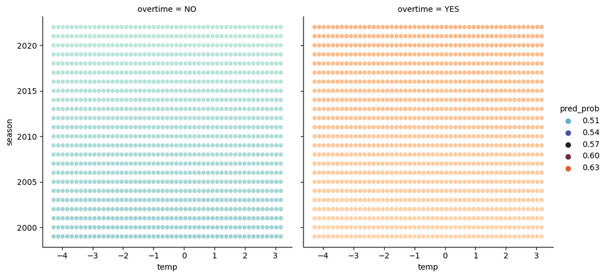

```python
viz_predict_prob_surface(fit_01, input_grid)
```

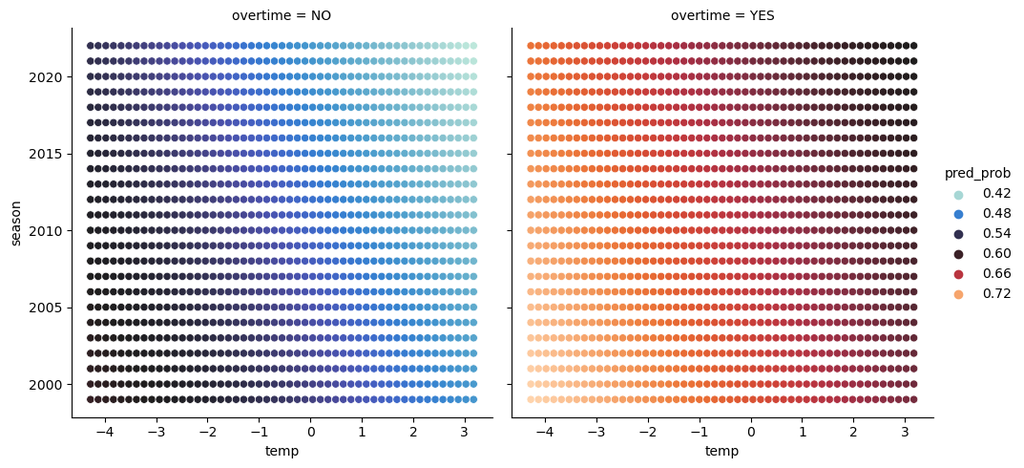

```python
viz_predict_prob_surface(fit_03, input_grid)
```

According to my two best models, it appears as if model 1 in the prediction grid is only split based off of the overtime input with a higher predicted probability if the game went into overtime.

On the flip side there is much more variation with model 3, as there is more impact by the other variables in season and temp. The highest prediction probability comes when there is overtime, the temperature is on the lower end.

### Tuning and Cross Validation

Elastic Net Models for two best `statsmodels` , Model 01 and Model 03.

Model 01

```python
my_cv = StratifiedKFold(n_splits =5, random_state = 101, shuffle = True)
```

```python
num_input_names = ['temp', 'wind', 'offense_ave_yards_gained_pass', 'offense_ave_yards_gained_run', 'defense_ave_yards_gained_pass', 'defense_ave_yards_gained_run', 'offense_completion_percentage']
```

```python
cat_inputs = ['overtime', 'season']
```

```python
cat_enet_wflow = Pipeline( steps = [('dummy', OneHotEncoder(drop = 'first')),
                                    ('enet', LogisticRegression(penalty='elasticnet', solver='saga', random_state=303, max_iter=25001))])
```

```python
enet_grid = {'enet__C': np.exp( np.linspace( np.log(0.0001), np.log(10000), num=15) ),
             'enet__l1_ratio': [0.0, 0.25, 0.5, 0.75, 1.0]}
```

```python
cat_enet_search = GridSearchCV( cat_enet_wflow, enet_grid, cv=my_cv)
```

```python
model_1_df = Xnfl_model.loc[:, cat_inputs].copy()
```

```python
cat_enet_search_results = cat_enet_search.fit( model_1_df.to_numpy(), Xnfl_model.point_total_reached.to_numpy().ravel() )
```

```python
cat_enet_search_results.best_params_
```

```
{'enet__C': 0.01930697728883252, 'enet__l1_ratio': 0.25}
```

```python
cat_enet_search_results.best_score_
```

```
0.5153853963612736
```

Elastic Net Model fitting Model 3

```python
numeric_transform = Pipeline(steps= [('std_input', StandardScaler())])
```

```python
categorical_transform = Pipeline( steps = [ ('dummy', OneHotEncoder(drop = 'first'))])
```

```python
preprocess_transform = ColumnTransformer( transformers = [('num', numeric_transform, num_input_names),
                                                         ('cat', categorical_transform, cat_inputs)])
```

```python
mix_enet_wflow = Pipeline( steps = [('prepro', preprocess_transform),
                                       ('enet', LogisticRegression(penalty = 'elasticnet', solver='saga', random_state=303, max_iter=25001))])
```

```python
mix_add_enet_search = GridSearchCV(mix_enet_wflow, enet_grid, cv=my_cv)
```

```python
Xnfl_inputs_df = Xnfl_model.loc[:, cat_inputs + num_input_names].copy()
Xnfl_inputs_df.head()
```

|  | overtime | season | temp | wind | offense_ave_yards_gained_pass | offense_ave_yards_gained_run | defense_ave_yards_gained_pass | defense_ave_yards_gained_run | offense_completion_percentage |
| --- | --- | --- | --- | --- | --- | --- | --- | --- | --- |
| 0 | NO | 1999.0 | 0.648553 | -1.042734 | -0.113607 | -2.380492 | 0.211645 | -0.019248 | -1.51126 |
| 1 | YES | 1999.0 | 0.648553 | -1.042734 | -0.113607 | -2.380492 | 0.211645 | -0.019248 | -1.51126 |
| 2 | NO | 1999.0 | 0.648553 | -1.042734 | -0.113607 | -2.380492 | 0.211645 | -0.019248 | -1.51126 |
| 3 | NO | 1999.0 | 0.648553 | -1.042734 | -0.113607 | -2.380492 | 0.211645 | -0.019248 | -1.51126 |
| 4 | NO | 1999.0 | 0.648553 | -1.042734 | -0.113607 | -2.380492 | 0.211645 | -0.019248 | -1.51126 |

```python
mix_add_enet_search_results = mix_add_enet_search.fit( Xnfl_inputs_df, Xnfl_model.point_total_reached.to_numpy().ravel() )
```

```python
mix_add_enet_search_results.best_params_
```

```
{'enet__C': 0.26826957952797276, 'enet__l1_ratio': 0.75}
```

```python
mix_add_enet_search_results.best_score_
```

```
0.5231166071041803
```

### Advanced Methods

Random Forest

```python
from sklearn.ensemble import RandomForestClassifier
```

```python
rf_wflow = Pipeline( steps = [('prepro', preprocess_transform),
                              ('rf', RandomForestClassifier(n_estimators = 500))])
```

```python
rf_grid = {'rf__max_features': [2,6,10,17,24,31]}
```

```python
rf_search = GridSearchCV(rf_wflow, rf_grid, cv=my_cv, scoring='r2')
```

```python
rf_search_results = rf_search.fit( Xnfl_inputs_df, Xnfl_model.point_total_reached.to_numpy().ravel())
```

```python
rf_search_results.best_params_
```

```
{'rf__max_features': 6}
```

```python
rf_search_results.best_score_
```

```
-0.9885757476606744
```

```python
rf_search_results.best_estimator_.named_steps['rf'].feature_importances_
```

```
array([0.25845187, 0.1963234 , 0.08233632, 0.08399426, 0.08440185,
       0.08444355, 0.08377899, 0.01453755, 0.00507016, 0.00489164,
       0.00508544, 0.00544769, 0.00493827, 0.00485132, 0.00458398,
       0.00516703, 0.00528489, 0.00492869, 0.00488201, 0.00504217,
       0.00517368, 0.00569213, 0.00468157, 0.00553964, 0.00550625,
       0.00475934, 0.00475813, 0.00482558, 0.00457876, 0.00448406,
       0.00155979])
```

```python
Xnfl_inputs_df
```

|  | overtime | season | temp | wind | offense_ave_yards_gained_pass | offense_ave_yards_gained_run | defense_ave_yards_gained_pass | defense_ave_yards_gained_run | offense_completion_percentage |
| --- | --- | --- | --- | --- | --- | --- | --- | --- | --- |
| 0 | NO | 1999.0 | 0.648553 | -1.042734 | -0.113607 | -2.380492 | 0.211645 | -0.019248 | -1.511260 |
| 1 | YES | 1999.0 | 0.648553 | -1.042734 | -0.113607 | -2.380492 | 0.211645 | -0.019248 | -1.511260 |
| 2 | NO | 1999.0 | 0.648553 | -1.042734 | -0.113607 | -2.380492 | 0.211645 | -0.019248 | -1.511260 |
| 3 | NO | 1999.0 | 0.648553 | -1.042734 | -0.113607 | -2.380492 | 0.211645 | -0.019248 | -1.511260 |
| 4 | NO | 1999.0 | 0.648553 | -1.042734 | -0.113607 | -2.380492 | 0.211645 | -0.019248 | -1.511260 |
| ... | ... | ... | ... | ... | ... | ... | ... | ... | ... |
| 6205 | NO | 2022.0 | 1.166768 | 1.104402 | -0.121769 | 0.621646 | -0.789380 | -0.115568 | 0.859849 |
| 6210 | NO | 2022.0 | 1.814536 | -0.863806 | -0.315297 | -1.577099 | -0.798156 | 0.686040 | 1.482168 |
| 6211 | NO | 2022.0 | 0.583776 | -0.863806 | -0.315297 | -1.577099 | -0.798156 | 0.686040 | 1.482168 |
| 6212 | NO | 2022.0 | 0.389446 | -0.148094 | -0.315297 | -1.577099 | -0.798156 | 0.686040 | 1.482168 |
| 6213 | NO | 2022.0 | 0.972437 | -0.863806 | -0.315297 | -1.577099 | -0.798156 | 0.686040 | 1.482168 |

6077 rows × 9 columns

```python
pd.DataFrame(preprocess_transform.fit_transform( Xnfl_inputs_df).toarray())
```

|  | 0 | 1 | 2 | 3 | 4 | 5 | 6 | 7 | 8 | 9 | ... | 21 | 22 | 23 | 24 | 25 | 26 | 27 | 28 | 29 | 30 |
| --- | --- | --- | --- | --- | --- | --- | --- | --- | --- | --- | --- | --- | --- | --- | --- | --- | --- | --- | --- | --- | --- |
| 0 | 0.642522 | -1.039356 | -0.118949 | -2.378606 | 0.211538 | -0.020013 | -1.504619 | 0.0 | 0.0 | 0.0 | ... | 0.0 | 0.0 | 0.0 | 0.0 | 0.0 | 0.0 | 0.0 | 0.0 | 0.0 | 0.0 |
| 1 | 0.642522 | -1.039356 | -0.118949 | -2.378606 | 0.211538 | -0.020013 | -1.504619 | 1.0 | 0.0 | 0.0 | ... | 0.0 | 0.0 | 0.0 | 0.0 | 0.0 | 0.0 | 0.0 | 0.0 | 0.0 | 0.0 |
| 2 | 0.642522 | -1.039356 | -0.118949 | -2.378606 | 0.211538 | -0.020013 | -1.504619 | 0.0 | 0.0 | 0.0 | ... | 0.0 | 0.0 | 0.0 | 0.0 | 0.0 | 0.0 | 0.0 | 0.0 | 0.0 | 0.0 |
| 3 | 0.642522 | -1.039356 | -0.118949 | -2.378606 | 0.211538 | -0.020013 | -1.504619 | 0.0 | 0.0 | 0.0 | ... | 0.0 | 0.0 | 0.0 | 0.0 | 0.0 | 0.0 | 0.0 | 0.0 | 0.0 | 0.0 |
| 4 | 0.642522 | -1.039356 | -0.118949 | -2.378606 | 0.211538 | -0.020013 | -1.504619 | 0.0 | 0.0 | 0.0 | ... | 0.0 | 0.0 | 0.0 | 0.0 | 0.0 | 0.0 | 0.0 | 0.0 | 0.0 | 0.0 |
| ... | ... | ... | ... | ... | ... | ... | ... | ... | ... | ... | ... | ... | ... | ... | ... | ... | ... | ... | ... | ... | ... |
| 6072 | 1.162812 | 1.108026 | -0.127106 | 0.620932 | -0.788291 | -0.116351 | 0.858443 | 0.0 | 0.0 | 0.0 | ... | 0.0 | 0.0 | 0.0 | 0.0 | 0.0 | 0.0 | 0.0 | 0.0 | 0.0 | 1.0 |
| 6073 | 1.813175 | -0.860408 | -0.320505 | -1.575908 | -0.797056 | 0.685415 | 1.478651 | 0.0 | 0.0 | 0.0 | ... | 0.0 | 0.0 | 0.0 | 0.0 | 0.0 | 0.0 | 0.0 | 0.0 | 0.0 | 1.0 |
| 6074 | 0.577486 | -0.860408 | -0.320505 | -1.575908 | -0.797056 | 0.685415 | 1.478651 | 0.0 | 0.0 | 0.0 | ... | 0.0 | 0.0 | 0.0 | 0.0 | 0.0 | 0.0 | 0.0 | 0.0 | 0.0 | 1.0 |
| 6075 | 0.382377 | -0.144614 | -0.320505 | -1.575908 | -0.797056 | 0.685415 | 1.478651 | 0.0 | 0.0 | 0.0 | ... | 0.0 | 0.0 | 0.0 | 0.0 | 0.0 | 0.0 | 0.0 | 0.0 | 0.0 | 1.0 |
| 6076 | 0.967704 | -0.860408 | -0.320505 | -1.575908 | -0.797056 | 0.685415 | 1.478651 | 0.0 | 0.0 | 0.0 | ... | 0.0 | 0.0 | 0.0 | 0.0 | 0.0 | 0.0 | 0.0 | 0.0 | 0.0 | 1.0 |

6077 rows × 31 columns

```python
rf_var_imp_df = pd.DataFrame({'feature_id': pd.DataFrame(preprocess_transform.fit_transform( Xnfl_inputs_df ).toarray()).columns,
                              'var_imp': rf_search_results.best_estimator_.named_steps['rf'].feature_importances_})
```

```python
rf_var_imp_df
```

|  | feature_id | var_imp |
| --- | --- | --- |
| 0 | 0 | 0.258452 |
| 1 | 1 | 0.196323 |
| 2 | 2 | 0.082336 |
| 3 | 3 | 0.083994 |
| 4 | 4 | 0.084402 |
| 5 | 5 | 0.084444 |
| 6 | 6 | 0.083779 |
| 7 | 7 | 0.014538 |
| 8 | 8 | 0.005070 |
| 9 | 9 | 0.004892 |
| 10 | 10 | 0.005085 |
| 11 | 11 | 0.005448 |
| 12 | 12 | 0.004938 |
| 13 | 13 | 0.004851 |
| 14 | 14 | 0.004584 |
| 15 | 15 | 0.005167 |
| 16 | 16 | 0.005285 |
| 17 | 17 | 0.004929 |
| 18 | 18 | 0.004882 |
| 19 | 19 | 0.005042 |
| 20 | 20 | 0.005174 |
| 21 | 21 | 0.005692 |
| 22 | 22 | 0.004682 |
| 23 | 23 | 0.005540 |
| 24 | 24 | 0.005506 |
| 25 | 25 | 0.004759 |
| 26 | 26 | 0.004758 |
| 27 | 27 | 0.004826 |
| 28 | 28 | 0.004579 |
| 29 | 29 | 0.004484 |
| 30 | 30 | 0.001560 |

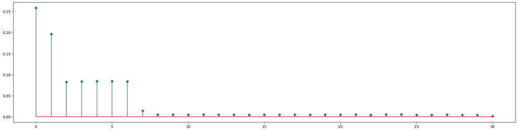

```python
fig, ax = plt.subplots(figsize=(25, 6))

ax.stem(rf_var_imp_df.feature_id, rf_var_imp_df.var_imp)

plt.show()
```

Gradient Boosted Forest

```python
from sklearn.ensemble import GradientBoostingClassifier
```

```python
gbm_to_fit = GradientBoostingClassifier()
```

```python
gbm_wflow = Pipeline(steps= [('prepro', preprocess_transform),
                            ('gbm', gbm_to_fit)])
```

```python
gbm_tune_grid = {'gbm__n_estimators': [25, 50, 100, 200],
                 'gbm__learning_rate': [0.01, 0.1],
                 'gbm__max_depth': [1, 3, 5]}
```

```python
gbm_search = GridSearchCV( gbm_wflow, gbm_tune_grid, cv=my_cv )
```

```python
gbm_search_results = gbm_search.fit( Xnfl_inputs_df, Xnfl_model.point_total_reached.to_numpy().ravel() )
```

```python
gbm_search_results.best_params_
```

```
{'gbm__learning_rate': 0.01, 'gbm__max_depth': 1, 'gbm__n_estimators': 200}
```

```python
gbm_search_results.best_score_
```

```
0.5282198938704787
```

```python
gbm_search_results.best_estimator_.named_steps['gbm'].feature_importances_
```

```
array([0.12169511, 0.        , 0.02474907, 0.        , 0.07592361,
       0.11261473, 0.02171423, 0.64330326, 0.        , 0.        ,
       0.        , 0.        , 0.        , 0.        , 0.        ,
       0.        , 0.        , 0.        , 0.        , 0.        ,
       0.        , 0.        , 0.        , 0.        , 0.        ,
       0.        , 0.        , 0.        , 0.        , 0.        ,
       0.        ])
```

```python
gbm_var_imp_df = pd.DataFrame({'feature_id': pd.DataFrame(preprocess_transform.fit_transform( Xnfl_inputs_df ).toarray()).columns,
                               'var_imp': gbm_search_results.best_estimator_.named_steps['gbm'].feature_importances_})
```

```python
gbm_var_imp_df
```

|  | feature_id | var_imp |
| --- | --- | --- |
| 0 | 0 | 0.121695 |
| 1 | 1 | 0.000000 |
| 2 | 2 | 0.024749 |
| 3 | 3 | 0.000000 |
| 4 | 4 | 0.075924 |
| 5 | 5 | 0.112615 |
| 6 | 6 | 0.021714 |
| 7 | 7 | 0.643303 |
| 8 | 8 | 0.000000 |
| 9 | 9 | 0.000000 |
| 10 | 10 | 0.000000 |
| 11 | 11 | 0.000000 |
| 12 | 12 | 0.000000 |
| 13 | 13 | 0.000000 |
| 14 | 14 | 0.000000 |
| 15 | 15 | 0.000000 |
| 16 | 16 | 0.000000 |
| 17 | 17 | 0.000000 |
| 18 | 18 | 0.000000 |
| 19 | 19 | 0.000000 |
| 20 | 20 | 0.000000 |
| 21 | 21 | 0.000000 |
| 22 | 22 | 0.000000 |
| 23 | 23 | 0.000000 |
| 24 | 24 | 0.000000 |
| 25 | 25 | 0.000000 |
| 26 | 26 | 0.000000 |
| 27 | 27 | 0.000000 |
| 28 | 28 | 0.000000 |
| 29 | 29 | 0.000000 |
| 30 | 30 | 0.000000 |

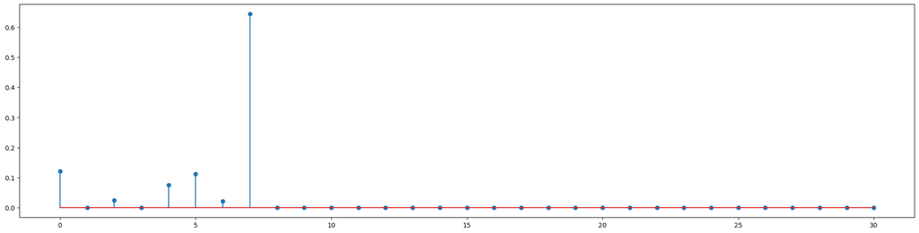

```python
fig, ax = plt.subplots(figsize=(25, 6))

ax.stem(gbm_var_imp_df.feature_id, gbm_var_imp_df.var_imp)

plt.show()
```

Support Vector Machine

```python
from sklearn.svm import SVC
```

```python
svm_rbf_wflow = Pipeline(steps = [('prepro', preprocess_transform),
                                 ('svm', SVC(gamma='scale', kernel='rbf', probability=True))])
```

```python
svm_rbf_tune_grid = {'svm__C': np.exp( np.linspace(np.log(0.001), np.log(1000), num=11) )}
```

```python
svm_rbf_search = GridSearchCV(svm_rbf_wflow, svm_rbf_tune_grid, cv=my_cv)
```

```python
svm_rbf_search_results = svm_rbf_search.fit( Xnfl_inputs_df, Xnfl_model.point_total_reached.to_numpy().ravel() )
```

```python
svm_rbf_search_results.best_params_
```

```
{'svm__C': 0.2511886431509581}
```

```python
svm_rbf_search_results.best_score_
```

```
0.5125908327918562
```

### Comparing Models

```python
def extract_model_performance(a_mod, a_name, num_folds):
    res = pd.DataFrame({'mean_test_score': a_mod.cv_results_['mean_test_score'],
                        'std_test_score': a_mod.cv_results_['std_test_score']})

    res['mean_test_score_se'] = res.std_test_score / np.sqrt( num_folds )

    res['model_name'] = a_name

    res.drop(['std_test_score'], axis=1, inplace=True)

    res_best = res.loc[ res.mean_test_score == res.mean_test_score.max(), :].copy()

    return res_best
```

```python
cv_results = pd.concat([extract_model_performance(cat_enet_search_results, 'ENET Model 1', my_cv.get_n_splits()),
                        extract_model_performance(mix_add_enet_search_results, 'ENET Model 3', my_cv.get_n_splits()),
                        extract_model_performance(svm_rbf_search_results, 'SVM RBF', my_cv.get_n_splits()),
                        extract_model_performance(rf_search_results, 'RF', my_cv.get_n_splits()),
                        extract_model_performance(gbm_search_results, 'GBM', my_cv.get_n_splits())])
```

```python
cv_results
```

|  | mean_test_score | mean_test_score_se | model_name |
| --- | --- | --- | --- |
| 21 | 0.515385 | 0.002140 | ENET Model 1 |
| 29 | 0.515385 | 0.002140 | ENET Model 1 |
| 33 | 0.523117 | 0.005174 | ENET Model 3 |
| 4 | 0.512591 | 0.005671 | SVM RBF |
| 1 | -0.988576 | 0.015414 | RF |
| 3 | 0.528220 | 0.004174 | GBM |

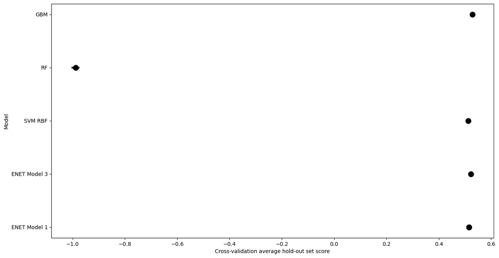

```python
fig, ax = plt.subplots(figsize=(15, 8))

ax.errorbar(y = cv_results.model_name,
            x = cv_results.mean_test_score,
            xerr = cv_results.mean_test_score_se,
            fmt = 'o', color = 'black', ecolor = 'black',
            elinewidth=3, ms=10)

ax.set_xlabel('Cross-validation average hold-out set score')
ax.set_ylabel('Model')

plt.show()
```

The performance metric appropriate to compare the models is the average performance score. The proper validation scheme for classification problems like mine is the StratifiedKFold cross validation. According to those metrics, the two statsmodels performed well against advanced models like Gradient Boosted Trees model and Support Vector Machine. The worst performing model by far was the Random Forest model. Further analysis can speak as to why this may be, but for this particular input we will advance to visualizing the best model which statistically was the Gradient Boosted Trees model on average.

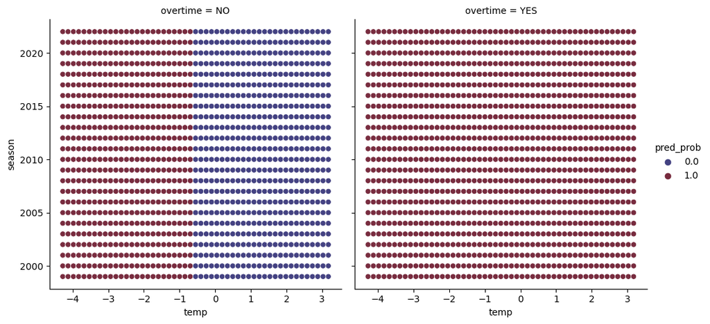

```python
viz_predict_prob_surface(gbm_search_results, input_grid)
```

```python
rf_viz_grid = pd.DataFrame([(temp, overtime, season, wind, offense_ave_yards_gained_pass, offense_ave_yards_gained_run, defense_ave_yards_gained_pass, defense_ave_yards_gained_run, offense_completion_percentage, points_allowed)
                        for temp in np.linspace(Xnfl_model.temp.min(), Xnfl_model.temp.max(), num = 51)
                        for overtime in Xnfl_model.overtime.unique()
                        for season in Xnfl_model.season.unique()
                        for wind in np.linspace(Xnfl_model.wind.min(), Xnfl_model.wind.max(), num = 51)
                        for offense_ave_yards_gained_pass in np.linspace(Xnfl_model.offense_ave_yards_gained_pass.mean(), Xnfl_model.offense_ave_yards_gained_pass.mean(), num = 1)
                        for offense_ave_yards_gained_run in np.linspace(Xnfl_model.offense_ave_yards_gained_run.mean(), Xnfl_model.offense_ave_yards_gained_run.mean(), num = 1)
                        for defense_ave_yards_gained_pass in np.linspace(Xnfl_model.defense_ave_yards_gained_pass.min(), Xnfl_model.defense_ave_yards_gained_pass.max(), num = 4)
                        for defense_ave_yards_gained_run in np.linspace(Xnfl_model.defense_ave_yards_gained_run.mean(), Xnfl_model.defense_ave_yards_gained_run.mean(), num = 1)
                        for offense_completion_percentage in np.linspace(Xnfl_model.offense_completion_percentage.mean(), Xnfl_model.offense_completion_percentage.mean(), num = 1)
                        for points_allowed in np.linspace(Xnfl_model.points_allowed.mean(), Xnfl_model.points_allowed.mean(), num = 1)],
            columns = ['temp', 'overtime', 'season', 'wind', 'offense_ave_yards_gained_pass', 'offense_ave_yards_gained_run', 'defense_ave_yards_gained_pass', 'defense_ave_yards_gained_run', 'offense_completion_percentage', 'points_allowed'])
```

```python
def rf_viz_predict_prob_surface(a_mod, input_df):

    viz_df = input_df.copy()

    viz_df['pred_prob'] = a_mod.predict( input_df )

    sns.relplot(data = viz_df, x='temp', y='wind', col='defense_ave_yards_gained_pass', hue='pred_prob',
                palette='icefire')

    plt.show()
```

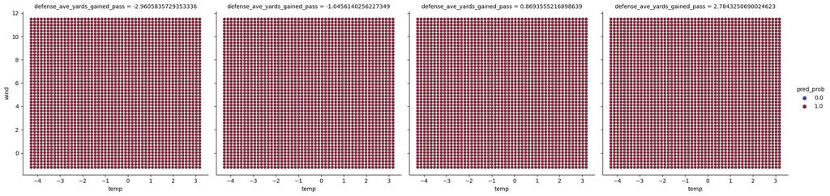

```python
rf_viz_predict_prob_surface(gbm_search_results, rf_viz_grid)
```

When the model is fit and predictions are made from the best model based on the best inputs accoring to random forest it appears to predict and classify the event at ALL points. This could be a signal as to why the random forest model performed so poorly compared to the other models. I am perplexed by this as surface level, the ranking inputs as mentioned earlier did not surprise me as they seem like inputs that could vastly affect scoring in NFL games. In the scope of this project I am unsure of the reason for this but am curious and motivated to be better at these sort of applications in the future so I will monitor feedback thoroughly.